# Assignment Week 2: Reproducable research

*What is mean total number of steps taken per day?*

**1. Calculate the total number of steps taken per day**

```r
if (!file.exists("activity.csv") )
    {
     dlurl <- 'http://d396qusza40orc.cloudfront.net/repdata%2Fdata%2Factivity.zip'
     download.file(dlurl,destfile='repdata%2Fdata%2Factivity.zip',mode='wb')
     unzip('repdata%2Fdata%2Factivity.zip')
}

data<- read.csv ("activity.csv")
```

```r
mean_steps_day <- aggregate(steps~date, data, sum)
```

**Make a histogram of the total number of steps taken each day**

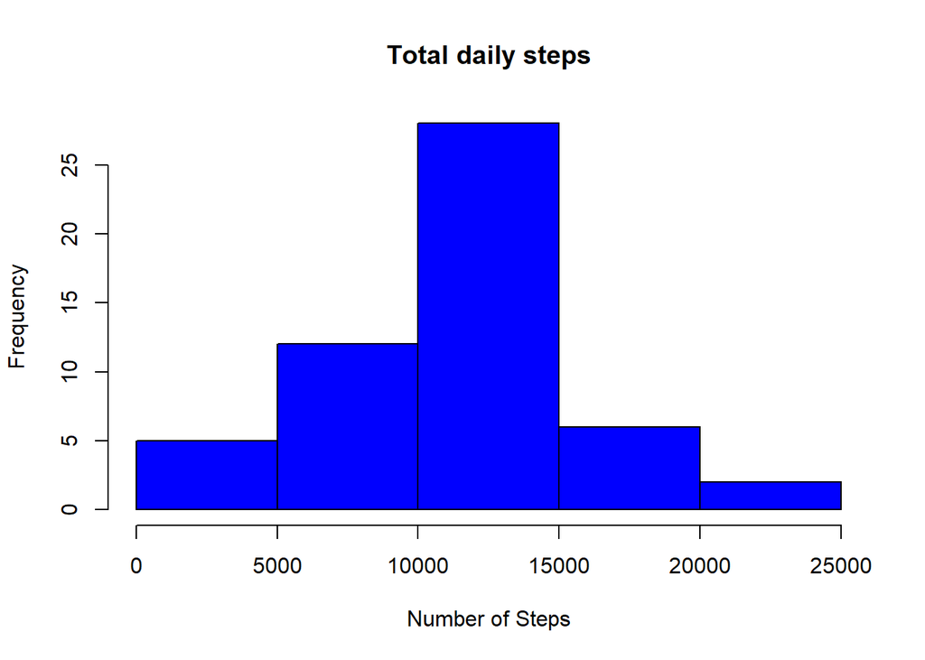

```r
hist(mean_steps_day$steps, main = paste("Total daily steps"), col="blue",xlab="Number of Steps")
```

```r
meansteps<-mean( mean_steps_day$steps)
meansteps
```

```
## [1] 10766.19
```

```r
mediansteps<-median(mean_steps_day$steps)
```

*What is the eaverage daily activity pattern?* **Make a time series plot (i.e. type=“l”) of the 5-minute interval (x-axis) and the average number of steps taken, averaged across all days (y-axis)**

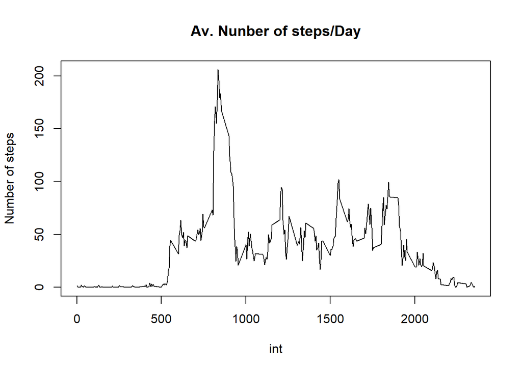

```r
Steps_interval<-aggregate(steps~interval, data, mean)
plot(Steps_interval$interval, Steps_interval$steps, type="l",  xlab= "int", ylab= "Number of steps", main= "Av. Nunber of steps/Day")
```

**Which 5-minute interval, on average across all the days in the dataset, contains the maximum number of steps?**

```r
max_int<- Steps_interval[which.max(Steps_interval$steps),1]
max_int
```

```
## [1] 835
```

The interval with the maximum steps is 835

*Imputing missing values*

**Calculate and report the total number of missing values in the dataset**

```r
NAtot<-sum(!complete.cases(data))
NAtot
```

```
## [1] 2304
```

there are 2304 missing values in the dataset